# Getting started

2018-07-07

Data Analysis Using R - 2018-07-07

## R is Case sensitive

*Important note: R is case-sensitive, meaning that it will matter whether you use capital or lower case, keep this in mind if you get a cryptic warning or error!*

## Cloud server for RStudio

- Preinstalled version of the R-IDE (integrated development environment) RStudio
- Runs on a remote server and has all the add-ons that are needed to run the code.
- Login with the credentials supplied at the beginning of the course.

To login to this server:

https://rserver.innovativetesting.nl

## RStudio interface

[figure not shown]

## Setting up package repositories

- Default RStudio has only enabled the CRAN repository, but there are other useful repositories that contain nice R packages.
- Enable the Bioconductor repositories (located at http://www.bioconductor.org) as packages from these repositories are often used in molecular biology.
- We only need to do this once, so the next time you start Rstudio it remembers which repositories are enabled.
- Type in the Console window (not the R script window!) the following command:

```r
setRepositories(graphics=TRUE)
```

## Initiate an RStudio project

From the File menu choose *New Project*, than choose *New Directory*. Provide the project with the name: *"r_course"*

## Cloning the course materials from Github.com

1. Create an account on www.github.com
2. Login in to github.com and go to www.github.com/uashogeschoolutrecht/daur_17_18
3. Copy the *url* address
4. Start a new project in RStudio-Server, choose *"Version Control"*
5. Copy the 'clone' link in the 'url' field, press enter
6. Let the clone finish

**Follow the steps above first before continuing**

Did it work? Please let me know if not.

## About this document: Literate programming

- This document is an R-markdown document.
- To create documents containing normal text, code and output of that code together.
- So-called *"Literate Programming"*
- Part of the "Reproducible research" philosophy.
- R Markdown can also include and interpret LaTeX, which is used much in the technical fields.
- It can render formulas's as well

## Example formula in LaTeX

Working_with_R = \(\sqrt[root](absolute(\frac{Participants\;fun}{much\;persistence}))\)

## Where do my files live?

- The root of a project can be defined by:

```r
if (!require("rprojroot")) install.packages("rprojroot")
library(rprojroot)
root <- find_root_file(criterion = is_rstudio_project)
root
```

```
## [1] "D:/r_projects/daur_17_18"
```

To see what the current working directory is, you can execute the command

`getwd()`

in the Console window. Try it now!

## Creating a new R script

- Start by creating an R script file that will contain all the steps taken to get to a certain result.
- Initially a scrapbook to note down what exactly you did.
- Annotate scripts with `# Comments`
- During this course, we will create a special R script file (`.Rmd`) for every exercise that contains the steps of that particular exercise (for instance a file named `"exercise_intro_to_r_exercise.Rmd"`).

## How to run the code in RStudio

This document contains code chunks:

````r
# a code chunk begins with ```{r}
y <- rnorm(100)
x <- sum(y)
x
hist(y)
# and ends with ```
````

## Running your first R-code

These so called code chunks contain R code that does something:

For example: calculate the mean of a number of random normal numbers. Without running the code, can you guess what the mean will approximately be? Why is it not eaxactly 10?

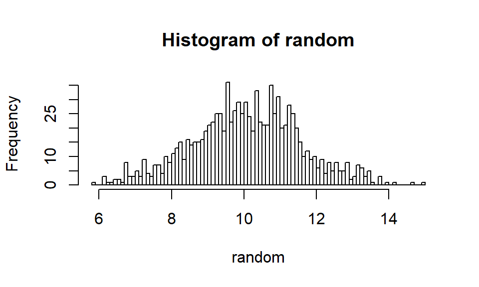

```r
set.seed(12345)
random <- rnorm(n = 1000, mean = 10, sd = 1.5)
mean(random)
hist(random, breaks = 80)
```

[output not shown]

## Run the code chunks as follows:

place the cursor somewhere in a code chunk and between the `` ```{r} `` and the `` ``` `` and press the keys:

`Ctrl` `Shift` and `Enter` simultaneously.

The code will run and the results will show either in the console, or below the code chunk.

## Run a line of code as follows:

- Place the cursor somewhere on the line that you want to run.
- Press the keys:

`Cntrl` and `Enter` simultaneously.

You can also run a piece of code by selecting the code by dragging the cursor and left-click mouse, and entering:

`Cntrl` and `Enter` simultaneously.